# clustering-6

```python
!jupyter nbconvert --execute --to html "/content/clustering-5.ipynb"
```

```
[NbConvertApp] Converting notebook /content/clustering-5.ipynb to html
[NbConvertApp] ERROR | unhandled iopub msg: colab_request
[NbConvertApp] ERROR | unhandled iopub msg: colab_request
[NbConvertApp] ERROR | unhandled iopub msg: colab_request
[NbConvertApp] Writing 2563740 bytes to /content/clustering-5.html
```

## Project 6 : Clustering

- Name: Ellie Mahoney
- Date: 03/16/23

## Instructions

### Description

Practice clustering on a using the well known and very popular `Iris` Dataset! The Iris flower data set is fun for learning supervised classification algorithms, and is known as a difficult case for unsupervised learning. https://cran.r-project.org/web/packages/dendextend/vignettes/Cluster_Analysis.html  
Yes, there are many examples out there, but see if you can do it yourself :). We can easily hypothesize on how many clusters would yield the best result, so let us prove it through a simple experiment that you could repeat with additional data sets.

### Grading

For grading purposes, we will clear all outputs from all your cells and then run them all from the top. Please test your notebook in the same fashion before turning it in.

### Submitting Your Solution

To submit your notebook, first clear all the cells (this won't matter too much this time, but for larger data sets in the future, it will make the file smaller). Then use the File->Download As->Notebook to obtain the notebook file. Finally, submit the notebook file on Canvas.

### Setup

```python
import matplotlib.pyplot as plt
from mpl_toolkits.mplot3d import Axes3D
from sklearn.decomposition import PCA
from sklearn import datasets
import sklearn as sk
import numpy as np
from mpl_toolkits.mplot3d import Axes3D
from sklearn.preprocessing import Normalizer
from sklearn.cluster import KMeans
```

### Problem 1: Data Generation (5 points)

Reference for more information: Chapter 5.11 K-Means in the online course book.

1. Load the `iris` dataset and separate into `X` and `y` variables (our ground truth labels will just be used for visualization).
2. Write a hypothesis on how many clusters will yield the best labeling.

```python
iris = datasets.load_iris()

X = iris.data
y = iris.target
```

**Hypothesis**(Edit this cell)

> The best number of clusters for labeling will be 4

### Problem 2: Data exploration (10 points)

This is the step where you would normally conduct any needed preprocessing, data wrangling, and investigation of the data.  
**Note:** `print(iris.DESCR)` prints the iris dataset description, provided you loaded it into a variable named `iris`

a. Using your skills from previous projects, provide code below to produce answers to the following questions (edit this cell with your answers):

```
1. How many features are provided?

4
```

```
2. How many total observations?

150
```

1. How many different labels are included, what are they called, and is it a balanced dataset with the same number of observations for each class?  
   3 labels: Iris-Setosa, Iris-Versicolour, Iris-Virginica. 50 of each therefore the dataset is balanced.  
   b. Create a 2D or 3D scatter plot of two or three of the features and use the y labels for color coding. Do not reduce the data or number of features in any way (you will do this by applying PCA in problem 5).

c. Since clusters can be influenced by the magnitudes of the variables, scale the feature data and plot a histogram of the transformed feature data (think about if you should use the min-max, standard scaler, or normalizer).

```python
# a


print(iris.DESCR)
```

```
.. _iris_dataset:

Iris plants dataset
--------------------

**Data Set Characteristics:**

    :Number of Instances: 150 (50 in each of three classes)
    :Number of Attributes: 4 numeric, predictive attributes and the class
    :Attribute Information:
        - sepal length in cm
        - sepal width in cm
        - petal length in cm
        - petal width in cm
        - class:
                - Iris-Setosa
                - Iris-Versicolour
                - Iris-Virginica

    :Summary Statistics:

    ============== ==== ==== ======= ===== ====================
                    Min  Max   Mean    SD   Class Correlation
    ============== ==== ==== ======= ===== ====================
    sepal length:   4.3  7.9   5.84   0.83    0.7826
    sepal width:    2.0  4.4   3.05   0.43   -0.4194
    petal length:   1.0  6.9   3.76   1.76    0.9490  (high!)
    petal width:    0.1  2.5   1.20   0.76    0.9565  (high!)
    ============== ==== ==== ======= ===== ====================

    :Missing Attribute Values: None
    :Class Distribution: 33.3% for each of 3 classes.
    :Creator: R.A. Fisher
    :Donor: Michael Marshall (MARSHALL%PLU@io.arc.nasa.gov)
    :Date: July, 1988

The famous Iris database, first used by Sir R.A. Fisher. The dataset is taken
from Fisher's paper. Note that it's the same as in R, but not as in the UCI
Machine Learning Repository, which has two wrong data points.

```

[output cut: 8 more lines]

```

   - Fisher, R.A. "The use of multiple measurements in taxonomic problems"
     Annual Eugenics, 7, Part II, 179-188 (1936); also in "Contributions to
     Mathematical Statistics" (John Wiley, NY, 1950).
   - Duda, R.O., & Hart, P.E. (1973) Pattern Classification and Scene Analysis.
     (Q327.D83) John Wiley & Sons.  ISBN 0-471-22361-1.  See page 218.
   - Dasarathy, B.V. (1980) "Nosing Around the Neighborhood: A New System
     Structure and Classification Rule for Recognition in Partially Exposed
     Environments".  IEEE Transactions on Pattern Analysis and Machine
     Intelligence, Vol. PAMI-2, No. 1, 67-71.
   - Gates, G.W. (1972) "The Reduced Nearest Neighbor Rule".  IEEE Transactions
     on Information Theory, May 1972, 431-433.
   - See also: 1988 MLC Proceedings, 54-64.  Cheeseman et al"s AUTOCLASS II
     conceptual clustering system finds 3 classes in the data.
   - Many, many more ...
```

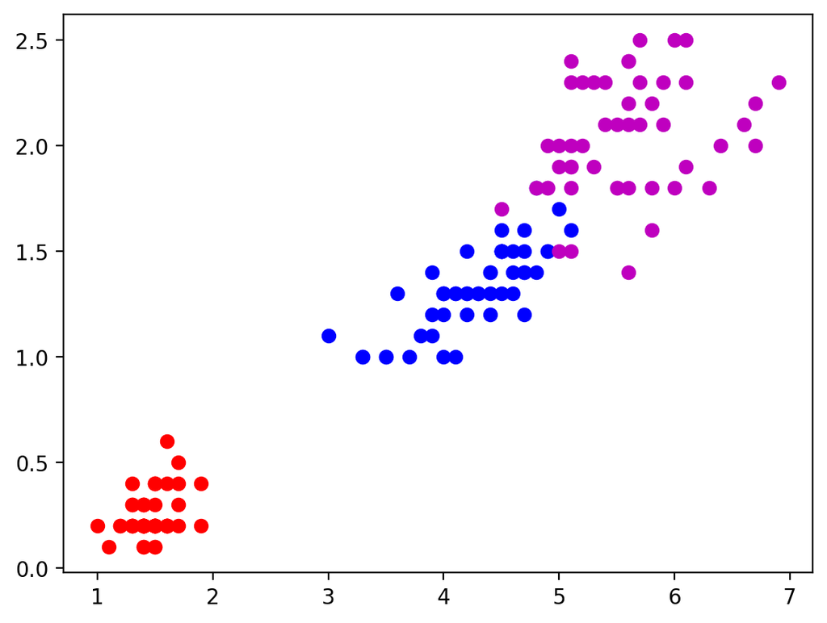

```python
# b
%matplotlib inline
%config InlineBackend.figure_format = 'retina'

target = range(len(iris.target_names))

#plot three clusters
for n, c in zip(target, 'r'+'b'+'m'):
    plt.scatter(X[y == n, 2], X[y == n, 3],c=c)
```

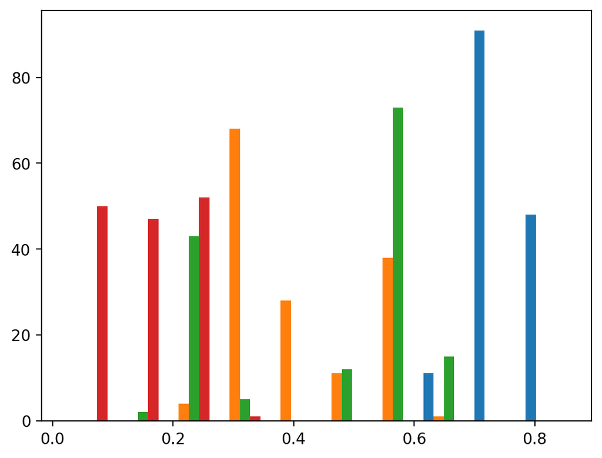

```python
#c. Scale the data (think about if you should use the min-max, standard scaler, or normalizer)
#define norm with sklearn
normalizer = Normalizer()

#fit model
normalizer.fit(X)
norm = normalizer.transform(X)

#plot histogram
plt.hist(norm)
plt.show()
```

### Problem 3: Unsupervised Learning - Clustering (15 points)

Conduct clustering experiments with one of algorithms discussed in class (e.g., k-means) for number of clusters k = 2-10. Create another 2D or 3D scatter plot utilizing the **cluster assignments** for color coding (this output can be a plot for each of the values of k or just one final plot using the value of k from your best Silhouette result obtained in Problem 4 below).

#### Steps:

Repeat for each value of k (maybe a loop here would be appropriate):

1. Create model object
2. Train or fit the model
3. Predict cluster assignments
4. Calculate Silhouette width (see Problem 4)
5. Plot points color coded by class labels predicted by the model.

```
k = 2
```

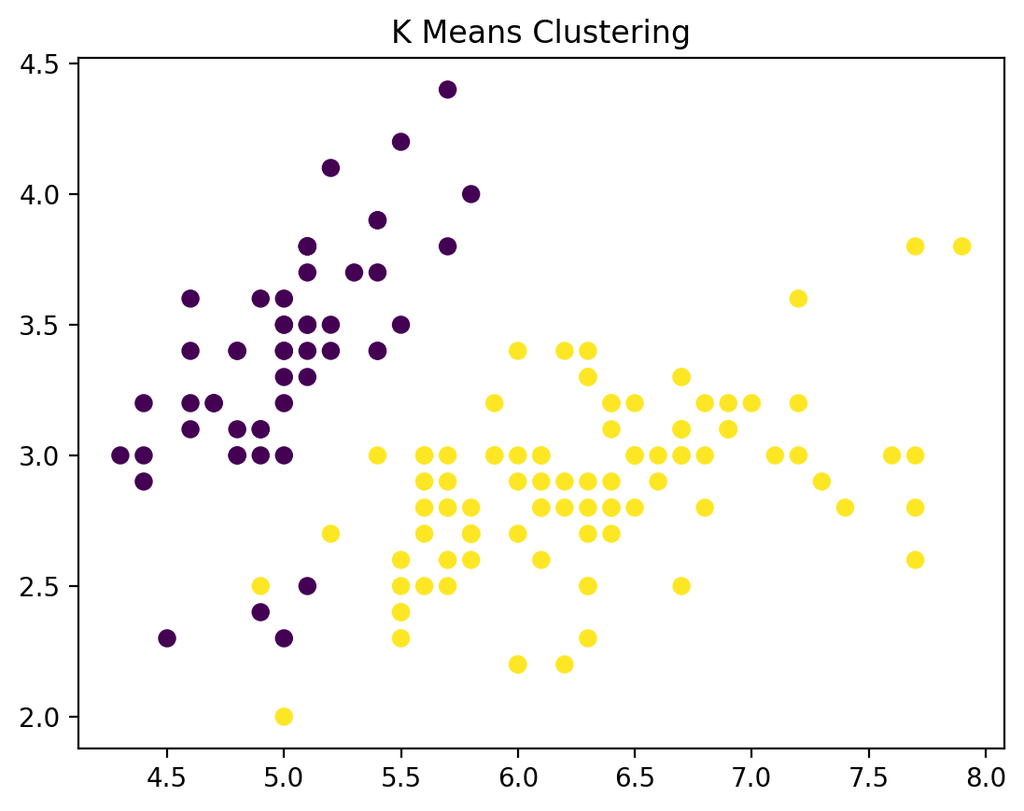

```
k = 3
```

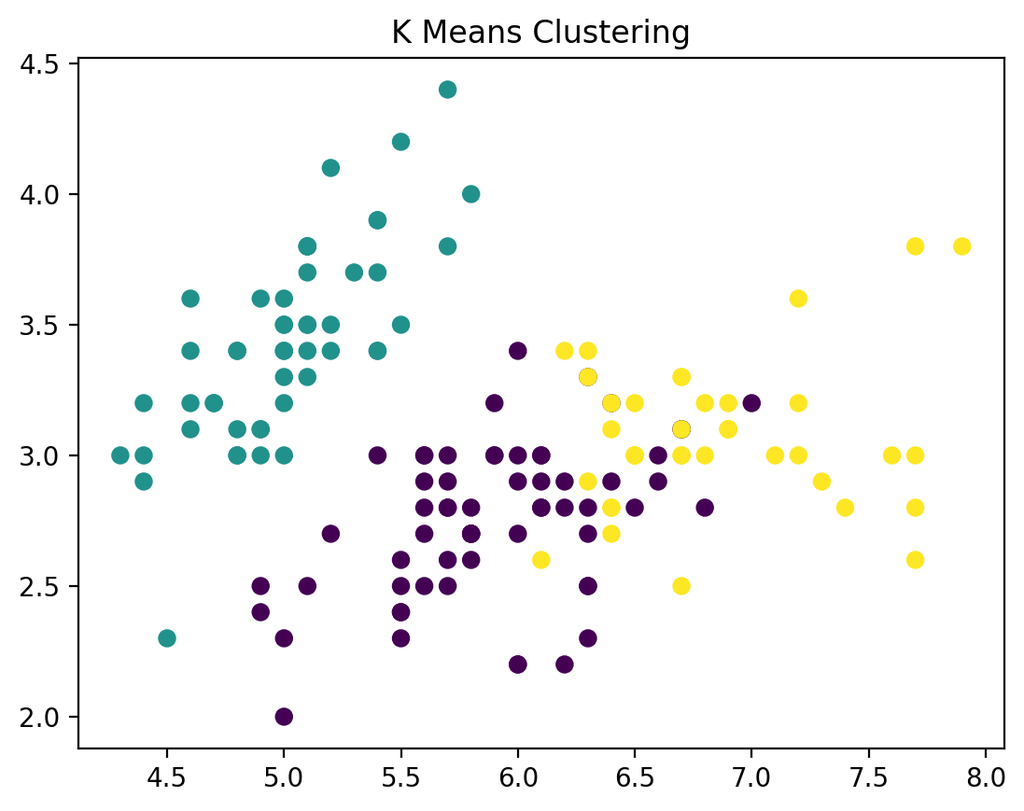

```
k = 4
```

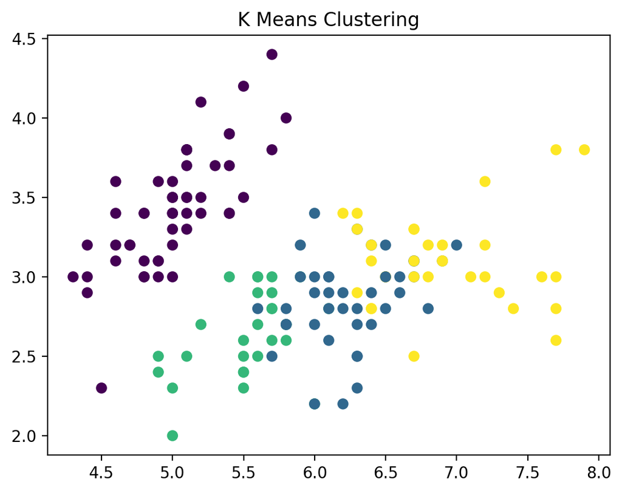

```
k = 5
```

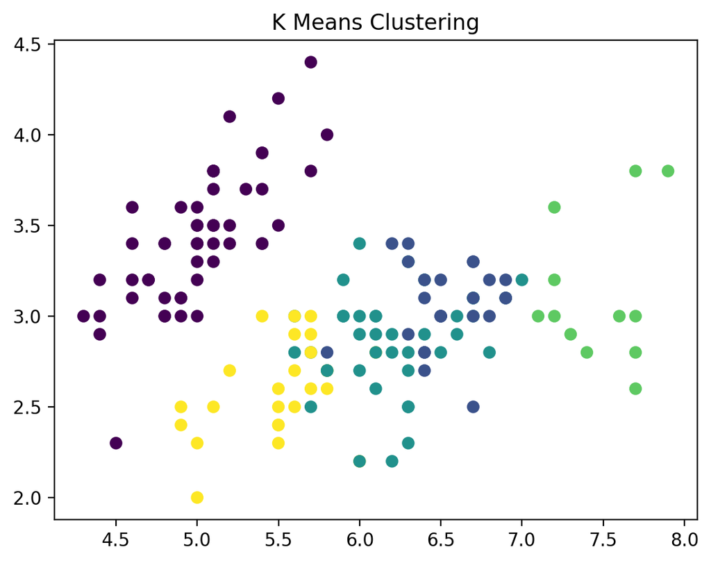

```
k = 6
```

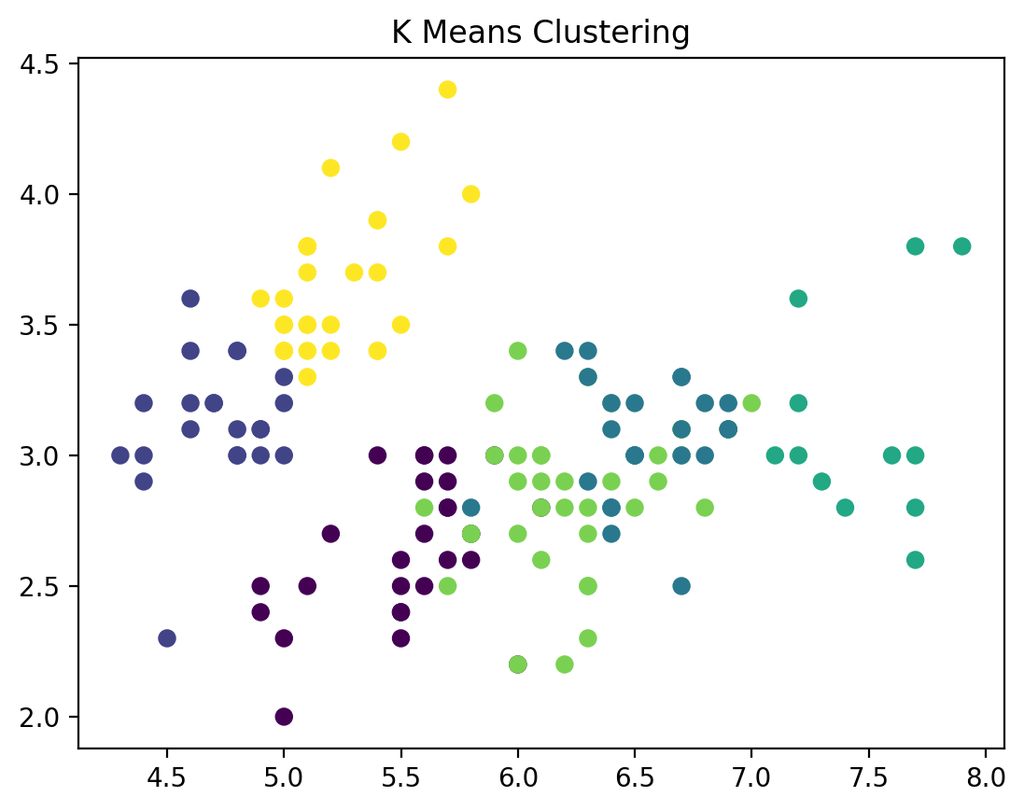

```
k = 7
```

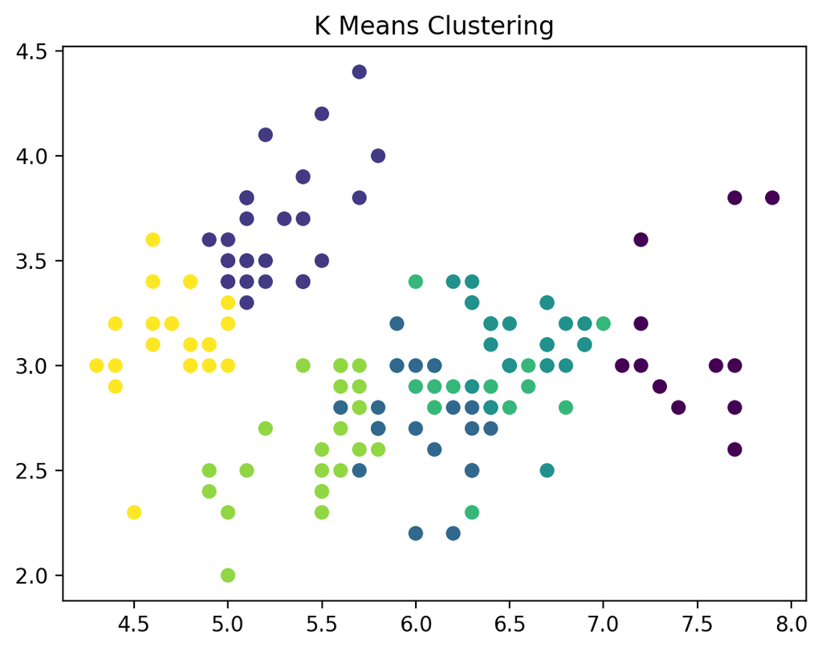

```
k = 8
```

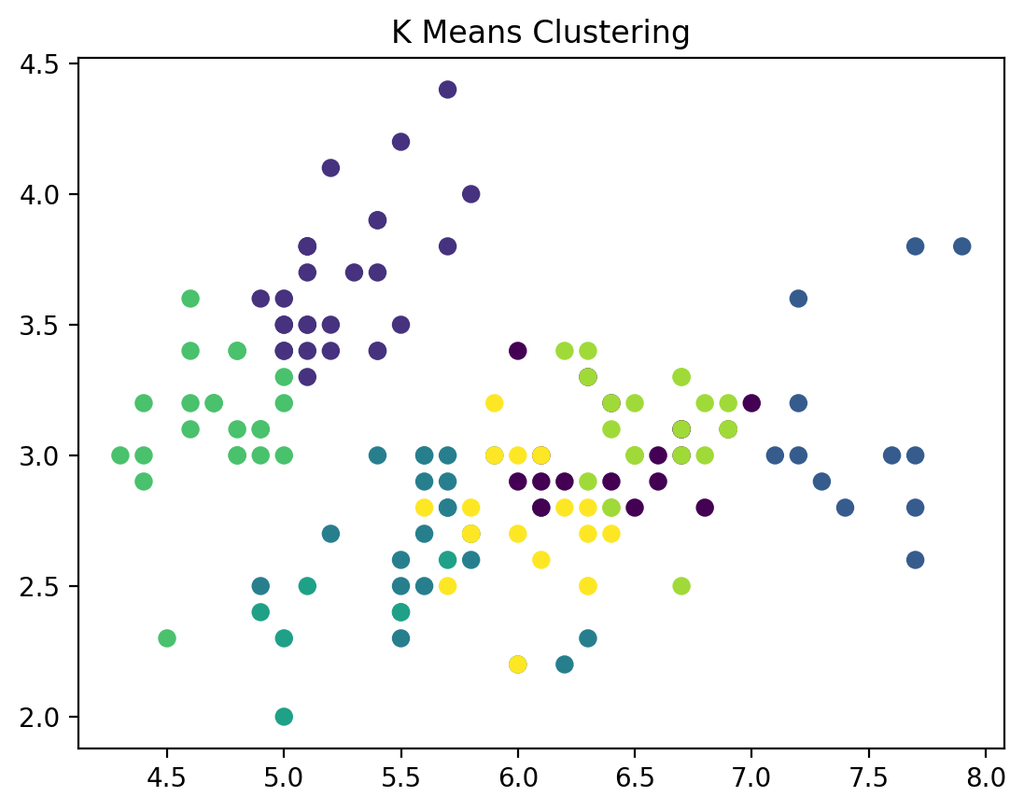

```
k = 9
```

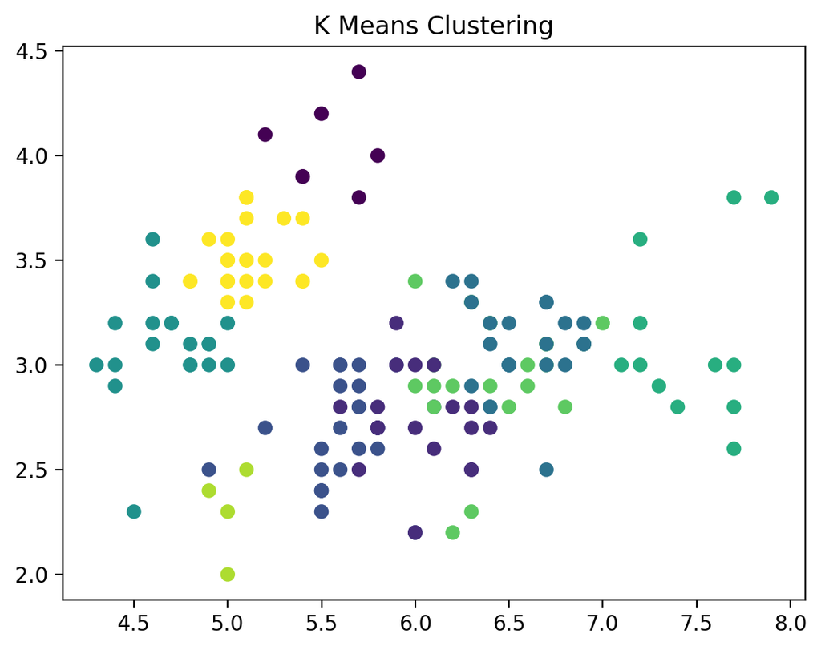

```
k = 10
```

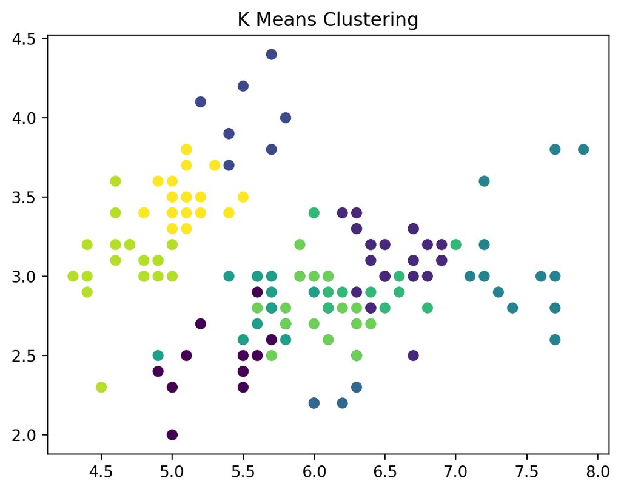

```python
# create list for silhoutte calculations

silhouttes_list = []

# k means algorithm for k = 2 through k = 10

k = 2

while k != 11:


    from sklearn.cluster import KMeans

    # Fit data

    km = KMeans(k)
    km.fit(X)

    # for labeling

    print('k =', k)

    # Calculate Silhoutte Score

    silhoutte_score = sk.metrics.silhouette_score(norm, km.labels_)
    silhouttes_list.append(silhoutte_score)

    # Plot

    plt.scatter(X[:,0], X[:,1], c=km.predict(X))
    plt.title('K Means Clustering')
    plt.show()

    k += 1
```

### Problem 4: Evaluate results (20 points)

As we have discussed, validating an usupervised problem is difficult. There is a metric that can be used to determine the density or separation of cluster assignments, called Silhouette width. In this step, perform analysis of results using the above `k = 2-10` and compute the Silhouette width (Hint: possibly you can just add code to your loop in problem 3 and store the results in a list of values).

Scikit Learn has a great example for Silhouette analysis [here](http://scikit-learn.org/stable/auto_examples/cluster/plot_kmeans_silhouette_analysis.html)

1. For each k (k = 2-10), what are the Silhouette width values?

   Shown in graph below.
2. Discuss if your best number of clusters (highest Silhouette width value) matches your hypothesis from Problem 1.

```
My hypothesis was k = 4, but this data suggests that k = 2 is optimal with a mean silhoutte over 0.6 considered a good silhoutte score.
```

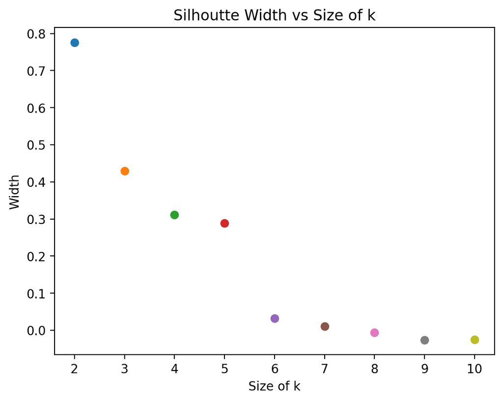

```python
#plot each k sizes silhoutte width

for c,s in zip([2,3,4,5,6,7,8,9,10], silhouttes_list
              ):
    plt.scatter(c,s)

#labels

plt.xlabel('Size of k')
plt.ylabel('Width')
plt.title('Silhoutte Width vs Size of k')
plt.show()
```

### Problem 5 (15 points): Principal Component Analysis (PCA)

PCA is the most popular form of dimensionality reduction, which basically, rotates and transforms the data into a new subspace, such that the resultant matrix has:

- Most relevance (variation) now associated with first feature
- Second feature gets the next most, etc. #### Steps:
1. Reduce the feature data (X) using PCA
2. Repeat the same experiment from problem 3 above (remember your plots are now the 1st, 2nd, and possibly 3rd principal component vs. the raw feature data like before).
3. Compare and contrast results to those from previous/non-PCA problems; does it perform better/worse/same? Provide discussion below (this could vary, depending on setup).

```
k = 2
```

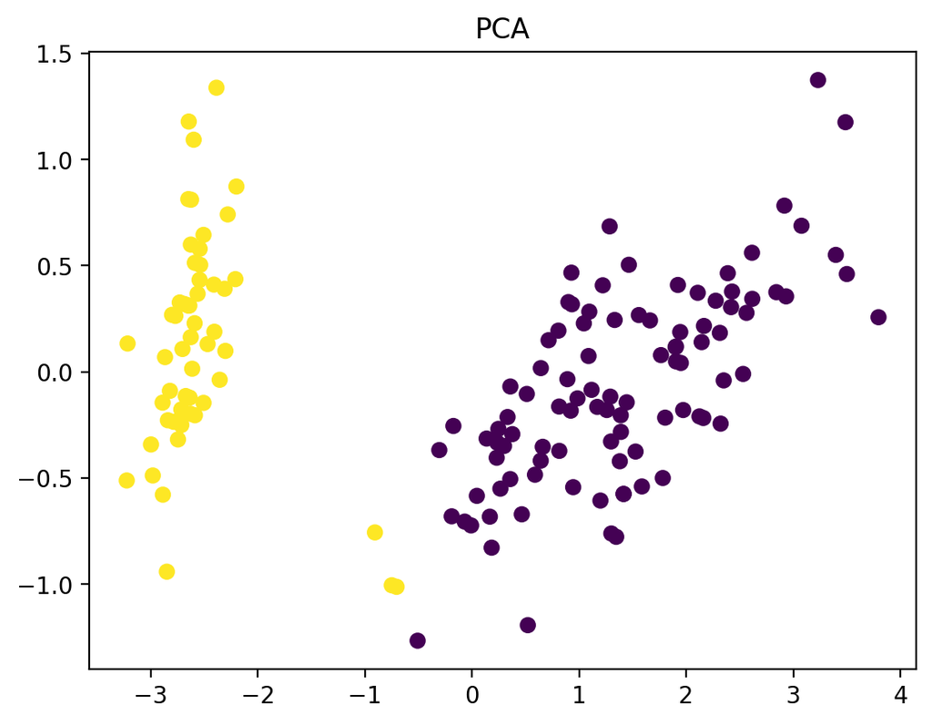

```
k = 3
```

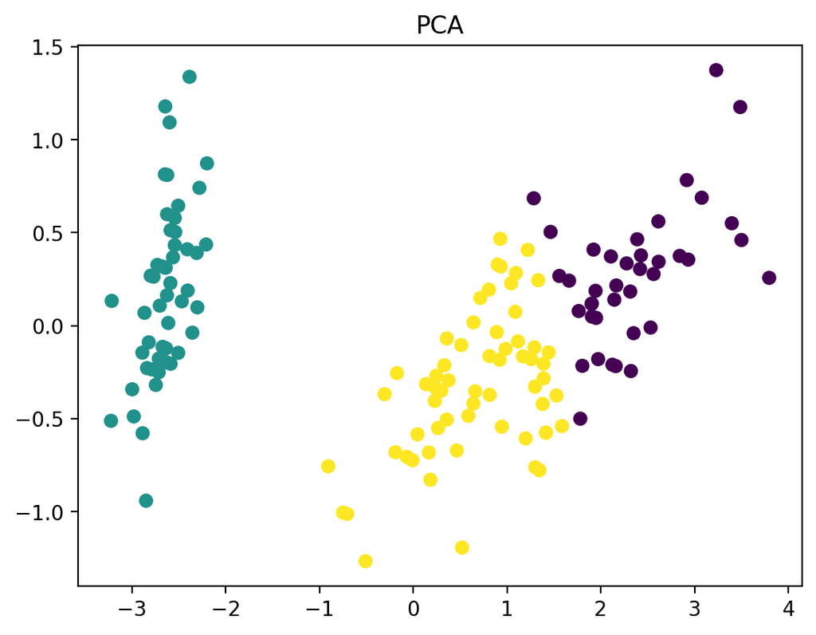

```
k = 4
```

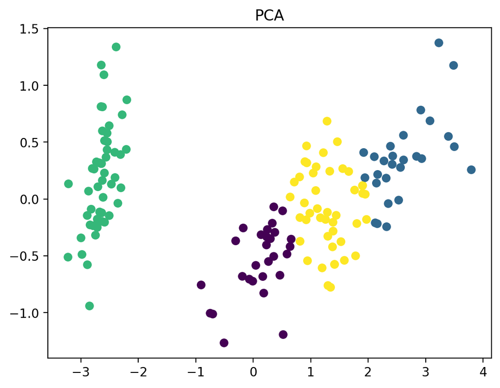

```
k = 5
```

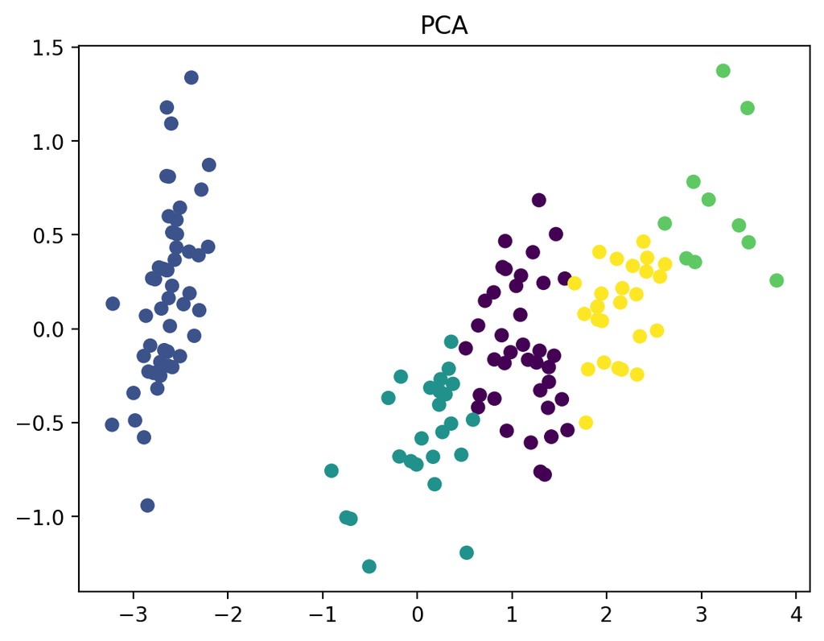

```
k = 6
```

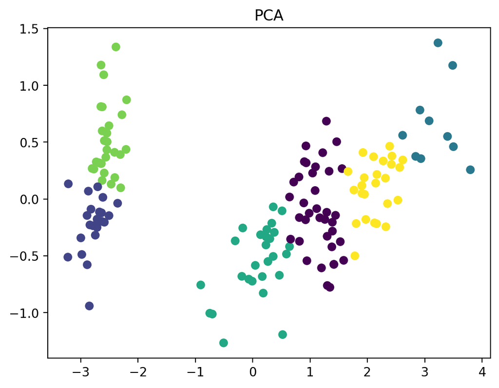

```
k = 7
```

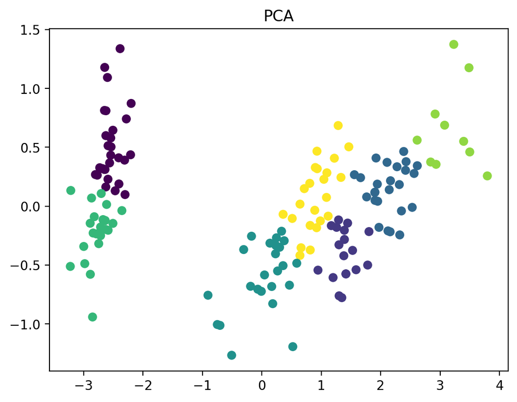

```
k = 8
```

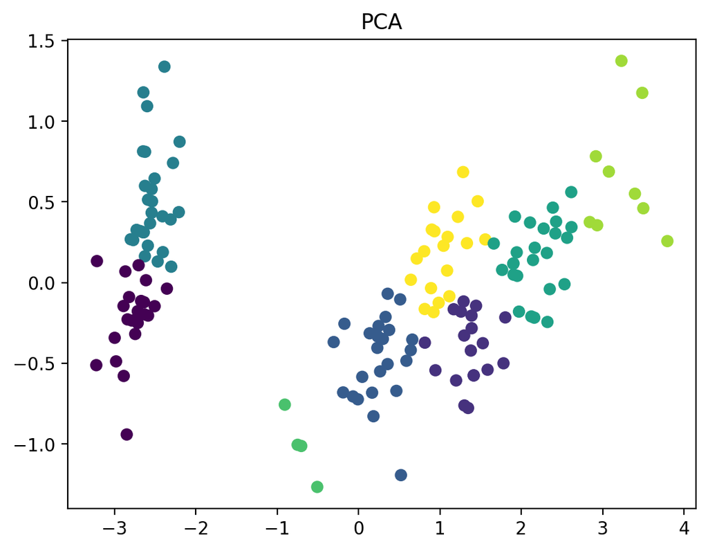

```
k = 9
```

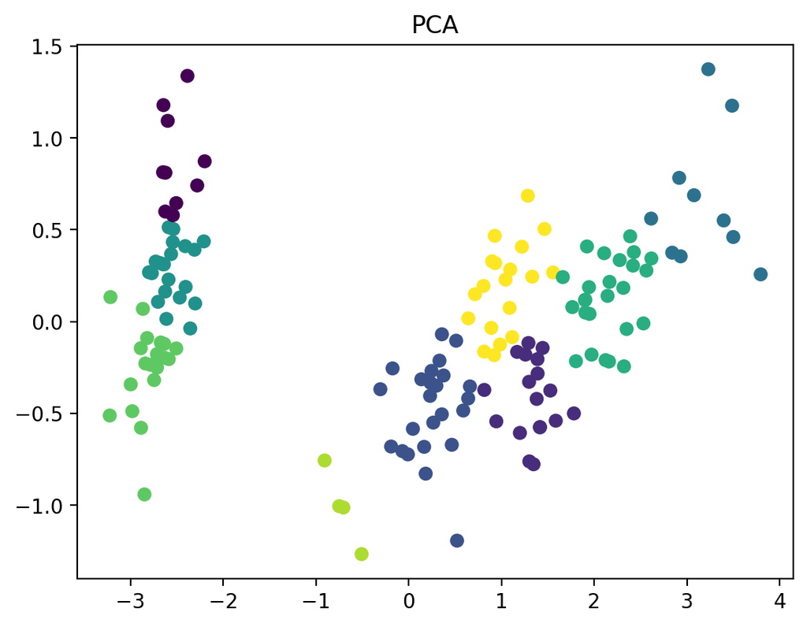

```
k = 10
```

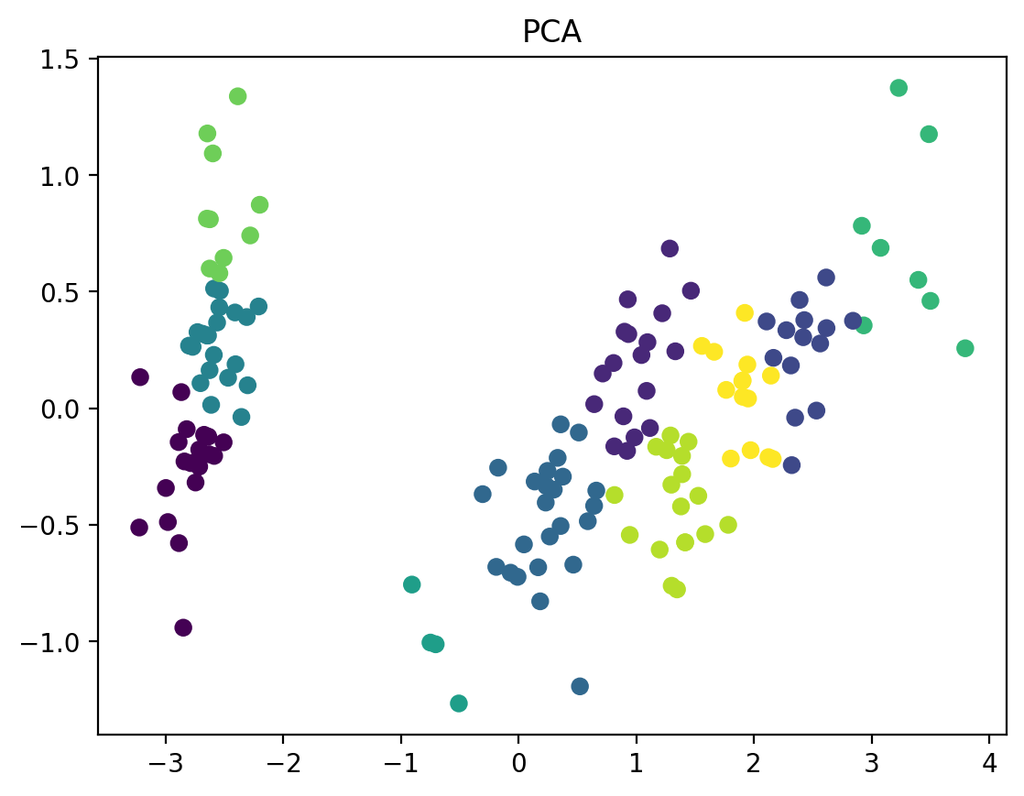

```python
# Clustering with PCA

# loop exact same code

from sklearn.decomposition import PCA

# create PCA object and telling how many objects we wsnt returned

pca = PCA(n_components=2)

# Fit Data

pca.fit(X)

# Transform data

data1_pca = pca.transform(X)

# Create list for silhoutte calculations

silhouttes = []

k = 2

# Same loop as before but different input

while k != 11:


    km = KMeans(k)
    km.fit(data1_pca)

    print('k =', k)

    silhoutte_score = sk.metrics.silhouette_score(norm, km.labels_)
    silhouttes.append(silhoutte_score)

    plt.scatter(data1_pca[:,0], data1_pca[:,1], c=km.predict(data1_pca))
    plt.title('PCA')
    plt.show()


    k += 1
```

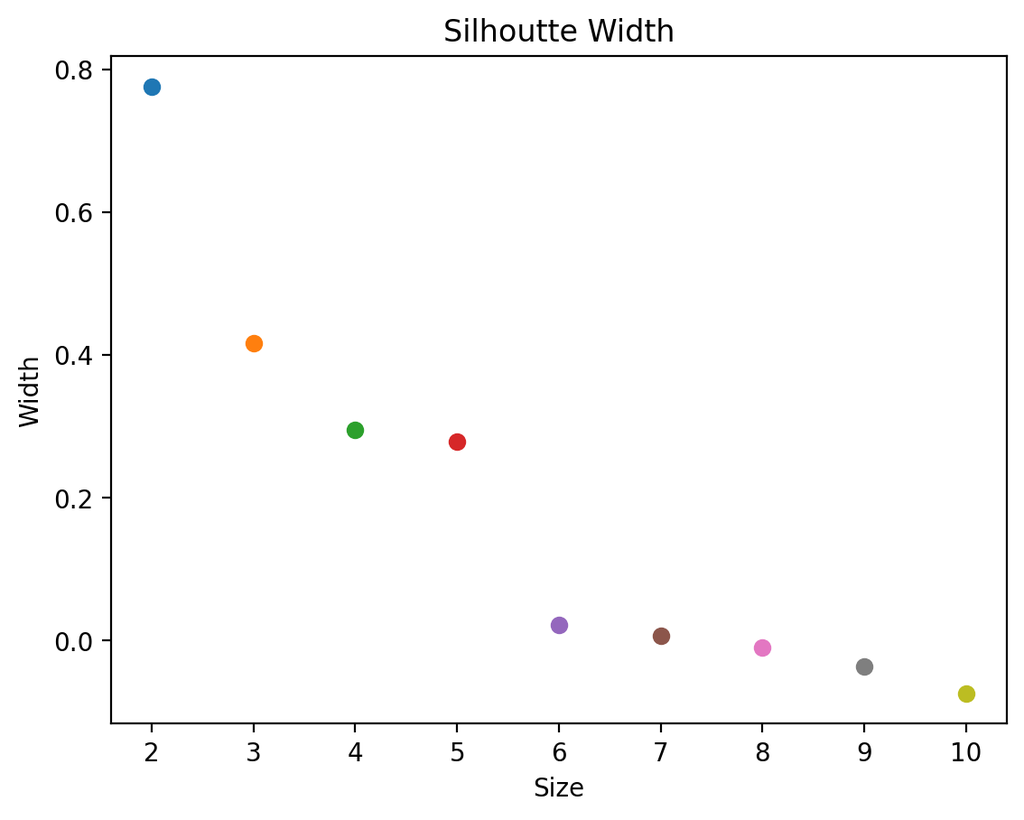

```python
# PCA evaluate silhoutte widths (same as before)

#plot each silhoutte width

for c,s in zip([2,3,4,5,6,7,8,9,10], silhouttes):
    plt.scatter(c,s)

#labels
plt.xlabel('Size')
plt.ylabel('Width')
plt.title('Silhoutte Width')
plt.show()
```

**Discuss new results**(Edit this cell)

> k = 2 is still optimal. As k increases, the clusters overlap more and more, increasing in variance.

## You Finished! Treat yourself by taking this questionnaire

### Questionnaire

1) How long did you spend on this assignment?  
4 hours  
2) What did you like about it? What did you not like about it?  
I liked using PCA.  
3) Did you find any errors or is there anything you would like changed?  
nope

Grade: 62/65 notes: -3 pts for not defining norm- I actually did define this as "normalizer" but wrote norm on another part of the assignment which confused the grader but this is fixed in this version.